# 1. Dataset Preparing (Tidak perlu diubah)

Dalam bagian ini akan menyiapkan dataset sampai siap untuk diolah atau dipreprocessing.  
Tensorflow: Package untuk machine learning / AI  
Numpy: Package untuk mengolah array  
Pandas: Package untuk mengolah dataset  
Pickle: Package untuk menyimpan variabel

```python
# Mengambil Package2 yang akan digunakan
import tensorflow as tf
import numpy as np
import pandas as pd
import pickle
```

```python
# Menggabungkan Netto_kg
df_aggregated = pd.read_csv('metadata_aggregated.csv')  # Membaca file
df_aggregated = df_aggregated.groupby(['tanggal', 'kecamatan']).agg(  # Menggabungkan banyak data dengan menjumlahkan 'netto_kg' untuk setiap 'tanggal' dan 'kecamatan' yang unik
    {
        'netto_kg': 'sum',
    }
).reset_index()
df_aggregated.head()
```

|  | tanggal | kecamatan | netto_kg |
| --- | --- | --- | --- |
| 0 | 01/01/2020 | Magelang Selatan | 12820 |
| 1 | 01/01/2020 | Magelang Tengah | 6750 |
| 2 | 01/01/2020 | Magelang Utara | 11195 |
| 3 | 01/01/2021 | Magelang Selatan | 18085 |
| 4 | 01/01/2021 | Magelang Tengah | 12510 |

```python
df_aggregated.info()  # menampilkan informasi tentang dataframe
```

```
<class 'pandas.core.frame.DataFrame'>
RangeIndex: 5249 entries, 0 to 5248
Data columns (total 3 columns):
 #   Column     Non-Null Count  Dtype
---  ------     --------------  -----
 0   tanggal    5249 non-null   object
 1   kecamatan  5249 non-null   object
 2   netto_kg   5249 non-null   int64
dtypes: int64(1), object(2)
memory usage: 123.1+ KB
```

```python
df_aggregated['kecamatan'].value_counts()  # menampilkan jumlah data setiap 'kecamatan'
```

```
Magelang Utara      1771
Magelang Selatan    1767
Magelang Tengah     1711
Name: kecamatan, dtype: int64
```

```python
# Mengimport package untuk mengolah waktu dan normalisasi data
from datetime import datetime, timedelta  # package untuk mengatur waktu/tanggal
from sklearn.preprocessing import MinMaxScaler  # package untuk normalisasi (MinMaxScaler)
```

Normalisasi adalah proses untuk mengubah rentang data menjadi rentang tertentu, salah satu metode Normalisasi adalah MinMaxScaler, dimana rentang data akan menjadi 0 sampai 1 dengan tujuan untuk menyeimbangkan data dan membuat training model tidak memiliki parameter yang terlalu besar.

```python
def min_max_normalize_dataframe(df, columns):  # Untuk normalisasi dataframe
    # Create a MinMaxScaler object
    scaler = MinMaxScaler()

    # Fit the scaler on the specified columns
    scaler.fit(df[columns])

    # Apply min-max normalization to the specified columns
    df[columns] = scaler.transform(df[columns])

    return df, scaler

def denormalize_dataframe(df, columns, scaler):  # Untuk mengembalikan dataframe ke bentuk semula sebelum normalisasi
    # Inverse transform the specified columns
    df[columns] = scaler.inverse_transform(df[columns])

    return df
```

```python
def fill_missing_dates(df):  # Untuk mengisi nilai kosong pada dataframe
    df['tanggal'] = pd.to_datetime(df['tanggal'], format='%d/%m/%Y', dayfirst=True)  # Mengubah format kolom 'tanggal' menjadi format tanggal, karena bisa saja kolom tersebut belum pada format tanggal
    df = df.set_index('tanggal')  # Mengubah index dataframe menjadi tanggal, hal ini digunakan karena ada fungsi bernama 'interpolate' pada pandas hanya bisa membaca index, sehingga kolom tanggal perlu diubah menjadi index

    # Generate a date range from the minimum to maximum date in the 'tanggal' column
    min_date = df.index.min()  # Menentukan tanggal terkecil (oldest)
    max_date = df.index.max()  # Menentukan tanggal terbesar (newest)
    date_range = pd.date_range(start=min_date, end=max_date)  # Menentukan rentang tanggal dari terkecil hingga terbesar

    df = df.reindex(date_range)  # Menambahkan data berisikan Null (data kosong) ke dataframe yang tidak memuat tanggal pada data_range (tanggal yang kosong)

    df['netto_kg'] = df['netto_kg'].interpolate(method='linear')  # Mengisi nilai yang Null tadi dengan interpolate menggunakan metode 'linear', artinya data diisi dengan rata-rata antara data sebelumnya dan data berikutnya yang diketahui

    df = df.reset_index()  # Mengembalikan tanggal yang tadinya sebagai index kembali menjadi kolom, namun nama kolomnya akan menjadi 'index' bukan 'tanggal'
    df = df.rename(columns={'index': 'tanggal'})  # Mengubah nama kolom 'index' kembali menjadi 'tanggal

    return df
```

```python
def check_missing_dates(df):  # Untuk menentukan/mengecek apakah ada tanggal kosong pada dataframe, hal ini digunakan sekali saja untuk mengecek
    # Generate a date range from the minimum to maximum date in the 'tanggal' column
    min_date = df['tanggal'].min()  # Menentukan tanggal terkecil
    max_date = df['tanggal'].max()  # Menentukan tanggal terbesar

    date_range = [min_date + timedelta(days=x) for x in range((max_date - min_date).days + 1)]  # Rentang tanggal

    temp_tanggal = df['tanggal'].values
    # Find missing dates
    missing_dates = [date for date in date_range if date not in temp_tanggal]

    # Print missing dates
    if missing_dates:
        print("Missing dates:")
        for date in missing_dates:
            print(date.strftime('%d/%m/%Y'))
    else:
        print("No missing dates found.")
```

```python
# Membagi dataset ke magelang utara, tengah, dan selatan, hal ini dikarenakan model yang akan kita buat harus terpisah antar kolom, sedangkan semua kecamatan masih berada pada satu kolom yaitu kolom 'kecamatan'
df_utara = df_aggregated[df_aggregated['kecamatan'] == 'Magelang Utara'].drop(columns='kecamatan').reset_index(drop=True)  # memisah dataframe untuk Magelang Utara
df_tengah = df_aggregated[df_aggregated['kecamatan'] == 'Magelang Tengah'].drop(columns='kecamatan').reset_index(drop=True)  # memisah dataframe untuk Magelang Tengah
df_selatan = df_aggregated[df_aggregated['kecamatan'] == 'Magelang Selatan'].drop(columns='kecamatan').reset_index(drop=True)  # Memisah dataframe untuk Magelang Selatan

df_utara = fill_missing_dates(df_utara).rename(columns={'netto_kg': 'magelang_utara'})  # mengisi tanggal kosong untuk Magelang Utara
df_tengah = fill_missing_dates(df_tengah).rename(columns={'netto_kg': 'magelang_tengah'})  # mengisi tanggal kosong untuk Magelang Tengah
df_selatan = fill_missing_dates(df_selatan).rename(columns={'netto_kg': 'magelang_selatan'})  # mengisi tanggal kosong untuk Magelang Selatan

df_timeseries = pd.merge(df_utara, df_tengah, 'left', 'tanggal')  # Menggabungkan kembali ketiga dataframe menjadi setiap kolom
df_timeseries = pd.merge(df_timeseries, df_selatan, 'left', 'tanggal')

df_timeseries, scaler = min_max_normalize_dataframe(df_timeseries, ['magelang_utara', 'magelang_tengah', 'magelang_selatan'])  # Normalisasi data dengan MinMaxScaler
df_timeseries.info()
```

```
<class 'pandas.core.frame.DataFrame'>
Int64Index: 1824 entries, 0 to 1823
Data columns (total 4 columns):
 #   Column            Non-Null Count  Dtype
---  ------            --------------  -----
 0   tanggal           1824 non-null   datetime64[ns]
 1   magelang_utara    1824 non-null   float64
 2   magelang_tengah   1824 non-null   float64
 3   magelang_selatan  1824 non-null   float64
dtypes: datetime64[ns](1), float64(3)
memory usage: 71.2 KB
```

```python
df_timeseries.head()  # Menampilkan 5 data pertama
```

|  | tanggal | magelang_utara | magelang_tengah | magelang_selatan |
| --- | --- | --- | --- | --- |
| 0 | 2019-01-03 | 0.174009 | 0.001101 | 0.116399 |
| 1 | 2019-01-04 | 0.637558 | 0.231447 | 0.123363 |
| 2 | 2019-01-05 | 0.552547 | 0.194891 | 0.173437 |
| 3 | 2019-01-06 | 0.592419 | 0.181238 | 0.283203 |
| 4 | 2019-01-07 | 0.848929 | 0.664832 | 0.528934 |

```python
df_timeseries.describe()  # Menampilkan informasi statistik
```

|  | magelang_utara | magelang_tengah | magelang_selatan |
| --- | --- | --- | --- |
| count | 1824.000000 | 1824.000000 | 1824.000000 |
| mean | 0.460543 | 0.451285 | 0.516479 |
| std | 0.180072 | 0.169291 | 0.184549 |
| min | 0.000000 | 0.000000 | 0.000000 |
| 25% | 0.363032 | 0.345959 | 0.406400 |
| 50% | 0.479326 | 0.460802 | 0.534240 |
| 75% | 0.584174 | 0.563312 | 0.647198 |
| max | 1.000000 | 1.000000 | 1.000000 |

```python
# membuat fungsi untuk membuat dataset, dataset harus berisikan input dan output yang tetap semisal input 5 hari sebelumnya untuk memprediksi output 30 hari setelahnya
def make_dataset(df, columns, input_timesteps=10, output_timesteps=10):
    # Iterate through the DataFrame to create input-output pairs
    X = []
    y = []
    for i in range(len(df) - input_timesteps - output_timesteps + 1):  # iterasi untuk setiap data
        X.append(df[columns].iloc[i:i+input_timesteps].values)
        y.append(df[columns].iloc[i+input_timesteps:i+input_timesteps+output_timesteps].values)

    # Convert the input-output pairs into numpy arrays
    X = np.array(X)
    y = np.array(y)

    print("Input shape:", X.shape)
    print("Output shape:", y.shape)

    return X, y
```

```python
# memperlihatkan jumlah dataset
X_30, y_30 = make_dataset(df_timeseries, ['magelang_utara', 'magelang_tengah', 'magelang_selatan'], input_timesteps=30, output_timesteps=366)  # Data dengan input 30 hari, output 366 hari
X_90, y_90 = make_dataset(df_timeseries, ['magelang_utara', 'magelang_tengah', 'magelang_selatan'], input_timesteps=90, output_timesteps=366)  # Data dengan input 90 hari, output 366 hari
X_366, y_366 = make_dataset(df_timeseries, ['magelang_utara', 'magelang_tengah', 'magelang_selatan'], input_timesteps=366, output_timesteps=366)  # Data dengan input 366 hari, output 366 hari
```

```
Input shape: (1429, 30, 3)
Output shape: (1429, 366, 3)
Input shape: (1369, 90, 3)
Output shape: (1369, 366, 3)
Input shape: (1093, 366, 3)
Output shape: (1093, 366, 3)
```

# 2. Modelling (Diubah sesuai model)

Setiap model dibagi menjadi 3, pertama inputnya timesteps 30, kedua 90, ketiga 366

## a. 30 Days LSTM

Model ini menggunakan 30 hari data sampah untuk memprediksi sampah tahun 2024

```python
from keras.callbacks import ModelCheckpoint
```

```python
# Membuat Model
model_LSTM = tf.keras.Sequential()  # Model lapisan, model ini akan berisi lapisan-lapisan (layers) machine learning
model_LSTM.add(tf.keras.layers.LSTM(64, return_sequences=True, input_shape=(30, 3)))  # Lapisan LSTM pertama
model_LSTM.add(tf.keras.layers.LSTM(64, return_sequences=True))  # Lapisan LSTM kedua
model_LSTM.add(tf.keras.layers.LSTM(256, return_sequences=False))  # Lapisan LSTM ketiga
model_LSTM.add(tf.keras.layers.Dense(1098, activation='relu'))  # Lapisan Dense untuk output
model_LSTM.add(tf.keras.layers.Reshape((366, 3)))  # Pembentukan output menjadi (366, 3) karena ada 366 hari dan 3 kecamatan
model_LSTM.summary()  # Melihat summary dari model
```

```
Model: "sequential_20"
_________________________________________________________________
 Layer (type)                Output Shape              Param #
=================================================================
 lstm_40 (LSTM)              (None, 30, 64)            17408

 lstm_41 (LSTM)              (None, 30, 64)            33024

 lstm_42 (LSTM)              (None, 256)               328704

 dense_15 (Dense)            (None, 1098)              282186

 reshape_12 (Reshape)        (None, 366, 3)            0

=================================================================
Total params: 661322 (2.52 MB)
Trainable params: 661322 (2.52 MB)
Non-trainable params: 0 (0.00 Byte)
_________________________________________________________________
```

```python
model_LSTM.compile(optimizer='adam', loss='mse')  # Compile model dengan optimizer 'adam' dan loss 'mse'
```

Secara teknikal, Optimizer adalah metode untuk mengubah bobot setiap parameter dengan 'loss' dan parameter tambahan yang diketahui  
ADAM (Adaptive Moment Estimation) adalah salah satu optimizer yang paling sering dipakai karena mudah untuk konvergen ke solusi

```python
checkpoint = ModelCheckpoint('best_LSTM_model.h5', monitor='val_loss', save_best_only=True, verbose=1)  # Checkpoint berfungsi untuk menyimpan model dengan kualitas terbaik
```

Setiap iterasi, model dengan validation loss terkecil akan disimpan.  
Data sendiri akan dibagi menjadi 20% Data Test dan 80% Data Train dengan 'validation_split=0.2'

```python
# Melatih Model
history = model_LSTM.fit(X_30, y_30, epochs=100, validation_split=0.2, callbacks=[checkpoint])
```

```
Epoch 1: val_loss improved from inf to 0.09574, saving model to best_LSTM_model.h5
Epoch 2: val_loss improved from 0.09574 to 0.09466, saving model to best_LSTM_model.h5
Epoch 3: val_loss improved from 0.09466 to 0.09441, saving model to best_LSTM_model.h5
Epoch 4: val_loss did not improve from 0.09441
Epoch 5: val_loss did not improve from 0.09441
Epoch 6: val_loss improved from 0.09441 to 0.09434, saving model to best_LSTM_model.h5
Epoch 7: val_loss improved from 0.09434 to 0.09416, saving model to best_LSTM_model.h5
Epoch 8: val_loss improved from 0.09416 to 0.09414, saving model to best_LSTM_model.h5
Epoch 9: val_loss did not improve from 0.09414
Epoch 10: val_loss improved from 0.09414 to 0.09392, saving model to best_LSTM_model.h5
Epoch 11: val_loss improved from 0.09392 to 0.09378, saving model to best_LSTM_model.h5
Epoch 12: val_loss improved from 0.09378 to 0.09306, saving model to best_LSTM_model.h5
Epoch 13: val_loss improved from 0.09306 to 0.09285, saving model to best_LSTM_model.h5
Epoch 14: val_loss improved from 0.09285 to 0.09274, saving model to best_LSTM_model.h5
Epoch 15: val_loss improved from 0.09274 to 0.09178, saving model to best_LSTM_model.h5
Epoch 16: val_loss improved from 0.09178 to 0.09054, saving model to best_LSTM_model.h5
Epoch 17: val_loss did not improve from 0.09054
Epoch 18: val_loss improved from 0.09054 to 0.08995, saving model to best_LSTM_model.h5
Epoch 19: val_loss improved from 0.08995 to 0.08958, saving model to best_LSTM_model.h5
Epoch 20: val_loss improved from 0.08958 to 0.08906, saving model to best_LSTM_model.h5
Epoch 21: val_loss improved from 0.08906 to 0.08792, saving model to best_LSTM_model.h5
Epoch 22: val_loss improved from 0.08792 to 0.08448, saving model to best_LSTM_model.h5
Epoch 23: val_loss improved from 0.08448 to 0.08311, saving model to best_LSTM_model.h5
Epoch 24: val_loss improved from 0.08311 to 0.08114, saving model to best_LSTM_model.h5
Epoch 25: val_loss improved from 0.08114 to 0.07963, saving model to best_LSTM_model.h5
Epoch 26: val_loss improved from 0.07963 to 0.07834, saving model to best_LSTM_model.h5
Epoch 27: val_loss improved from 0.07834 to 0.07652, saving model to best_LSTM_model.h5
Epoch 28: val_loss did not improve from 0.07652
Epoch 29: val_loss improved from 0.07652 to 0.07590, saving model to best_LSTM_model.h5
Epoch 30: val_loss improved from 0.07590 to 0.07481, saving model to best_LSTM_model.h5
Epoch 31: val_loss improved from 0.07481 to 0.07444, saving model to best_LSTM_model.h5
Epoch 32: val_loss improved from 0.07444 to 0.07364, saving model to best_LSTM_model.h5
Epoch 33: val_loss improved from 0.07364 to 0.07354, saving model to best_LSTM_model.h5
Epoch 34: val_loss improved from 0.07354 to 0.07350, saving model to best_LSTM_model.h5
Epoch 35: val_loss improved from 0.07350 to 0.07253, saving model to best_LSTM_model.h5
Epoch 36: val_loss improved from 0.07253 to 0.07150, saving model to best_LSTM_model.h5
Epoch 37: val_loss improved from 0.07150 to 0.06985, saving model to best_LSTM_model.h5
Epoch 38: val_loss improved from 0.06985 to 0.06912, saving model to best_LSTM_model.h5
Epoch 39: val_loss improved from 0.06912 to 0.06748, saving model to best_LSTM_model.h5
Epoch 40: val_loss improved from 0.06748 to 0.06679, saving model to best_LSTM_model.h5
```

[output cut: 45 more lines]

```
Epoch 86: val_loss did not improve from 0.03123
Epoch 87: val_loss did not improve from 0.03123
Epoch 88: val_loss did not improve from 0.03123
Epoch 89: val_loss did not improve from 0.03123
Epoch 90: val_loss did not improve from 0.03123
Epoch 91: val_loss did not improve from 0.03123
Epoch 92: val_loss did not improve from 0.03123
Epoch 93: val_loss did not improve from 0.03123
Epoch 94: val_loss did not improve from 0.03123
Epoch 95: val_loss did not improve from 0.03123
Epoch 96: val_loss did not improve from 0.03123
Epoch 97: val_loss did not improve from 0.03123
Epoch 98: val_loss did not improve from 0.03123
Epoch 99: val_loss did not improve from 0.03123
Epoch 100: val_loss did not improve from 0.03123
```

```python
import matplotlib.pyplot as plt  # Package untuk visualisasi data
```

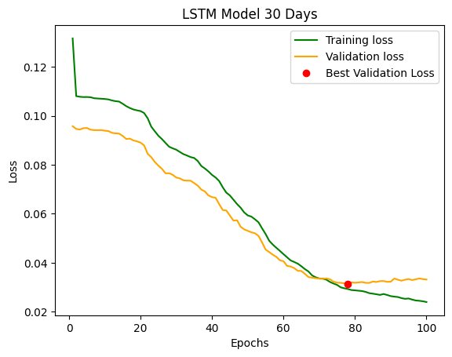

```python
# Visualisasi model
# Get the training loss from the history
loss = history.history['loss']
# Get the validation loss from the history
val_loss = history.history['val_loss']

# Get the number of epochs
epochs = range(1, len(loss) + 1)

# Plot training loss in green
plt.plot(epochs, loss, 'g', label='Training loss')

# Find the epoch with the best validation loss
best_epoch = val_loss.index(min(val_loss)) + 1

# Plot validation loss in orange
plt.plot(epochs, val_loss, 'orange', label='Validation loss')
# Mark the epoch with the best validation loss
plt.plot(best_epoch, min(val_loss), 'ro', label='Best Validation Loss')

plt.title('LSTM Model 30 Days')
plt.xlabel('Epochs')
plt.ylabel('Loss')
plt.legend()
plt.show()
```

```python
with open("history.pkl", 'wb') as f:  # Menyimpan history model
    pickle.dump(history, f)
```

## b. 90 Days LSTM

Sama dengan sebelumnya, melainkan kali ini menggunakan 90 hari untuk memprediksi sampah 2024

```python
from keras.callbacks import ModelCheckpoint
```

```python
model_LSTM_90 = tf.keras.Sequential()
model_LSTM_90.add(tf.keras.layers.LSTM(64, return_sequences=True, input_shape=(90, 3)))
model_LSTM_90.add(tf.keras.layers.LSTM(64, return_sequences=True))
model_LSTM_90.add(tf.keras.layers.LSTM(256, return_sequences=False))
model_LSTM_90.add(tf.keras.layers.Dense(1098, activation='relu'))
model_LSTM_90.add(tf.keras.layers.Reshape((366, 3)))
model_LSTM_90.summary()
```

```
Model: "sequential_21"
_________________________________________________________________
 Layer (type)                Output Shape              Param #
=================================================================
 lstm_43 (LSTM)              (None, 90, 64)            17408

 lstm_44 (LSTM)              (None, 90, 64)            33024

 lstm_45 (LSTM)              (None, 256)               328704

 dense_16 (Dense)            (None, 1098)              282186

 reshape_13 (Reshape)        (None, 366, 3)            0

=================================================================
Total params: 661322 (2.52 MB)
Trainable params: 661322 (2.52 MB)
Non-trainable params: 0 (0.00 Byte)
_________________________________________________________________
```

```python
model_LSTM_90.compile(optimizer='adam', loss='mse')
```

```python
checkpoint_90 = ModelCheckpoint('best_LSTM_90_model.h5', monitor='val_loss', save_best_only=True, verbose=1)
```

```python
history_90 = model_LSTM_90.fit(X_90, y_90, epochs=100, validation_split=0.2, callbacks=[checkpoint_90])
```

```
Epoch 1: val_loss improved from inf to 0.09376, saving model to best_LSTM_90_model.h5
```

```
Epoch 2: val_loss improved from 0.09376 to 0.09177, saving model to best_LSTM_90_model.h5
Epoch 3: val_loss did not improve from 0.09177
Epoch 4: val_loss improved from 0.09177 to 0.09164, saving model to best_LSTM_90_model.h5
Epoch 5: val_loss did not improve from 0.09164
Epoch 6: val_loss did not improve from 0.09164
Epoch 7: val_loss did not improve from 0.09164
Epoch 8: val_loss improved from 0.09164 to 0.09135, saving model to best_LSTM_90_model.h5
Epoch 9: val_loss improved from 0.09135 to 0.09035, saving model to best_LSTM_90_model.h5
Epoch 10: val_loss improved from 0.09035 to 0.08989, saving model to best_LSTM_90_model.h5
Epoch 11: val_loss improved from 0.08989 to 0.08916, saving model to best_LSTM_90_model.h5
Epoch 12: val_loss did not improve from 0.08916
Epoch 13: val_loss did not improve from 0.08916
Epoch 14: val_loss improved from 0.08916 to 0.08843, saving model to best_LSTM_90_model.h5
Epoch 15: val_loss improved from 0.08843 to 0.08760, saving model to best_LSTM_90_model.h5
Epoch 16: val_loss did not improve from 0.08760
Epoch 17: val_loss improved from 0.08760 to 0.08698, saving model to best_LSTM_90_model.h5
Epoch 18: val_loss did not improve from 0.08698
Epoch 19: val_loss improved from 0.08698 to 0.08594, saving model to best_LSTM_90_model.h5
Epoch 20: val_loss did not improve from 0.08594
Epoch 21: val_loss improved from 0.08594 to 0.08432, saving model to best_LSTM_90_model.h5
Epoch 22: val_loss improved from 0.08432 to 0.08331, saving model to best_LSTM_90_model.h5
Epoch 23: val_loss improved from 0.08331 to 0.07835, saving model to best_LSTM_90_model.h5
Epoch 24: val_loss improved from 0.07835 to 0.07690, saving model to best_LSTM_90_model.h5
Epoch 25: val_loss improved from 0.07690 to 0.07363, saving model to best_LSTM_90_model.h5
Epoch 26: val_loss improved from 0.07363 to 0.07264, saving model to best_LSTM_90_model.h5
Epoch 27: val_loss improved from 0.07264 to 0.07164, saving model to best_LSTM_90_model.h5
Epoch 28: val_loss improved from 0.07164 to 0.07027, saving model to best_LSTM_90_model.h5
Epoch 29: val_loss did not improve from 0.07027
Epoch 30: val_loss improved from 0.07027 to 0.06996, saving model to best_LSTM_90_model.h5
Epoch 31: val_loss did not improve from 0.06996
Epoch 32: val_loss improved from 0.06996 to 0.06990, saving model to best_LSTM_90_model.h5
Epoch 33: val_loss did not improve from 0.06990
Epoch 34: val_loss improved from 0.06990 to 0.06892, saving model to best_LSTM_90_model.h5
Epoch 35: val_loss did not improve from 0.06892
Epoch 36: val_loss improved from 0.06892 to 0.06820, saving model to best_LSTM_90_model.h5
Epoch 37: val_loss did not improve from 0.06820
Epoch 38: val_loss improved from 0.06820 to 0.06672, saving model to best_LSTM_90_model.h5
Epoch 39: val_loss improved from 0.06672 to 0.06540, saving model to best_LSTM_90_model.h5
Epoch 40: val_loss improved from 0.06540 to 0.06445, saving model to best_LSTM_90_model.h5
Epoch 41: val_loss improved from 0.06445 to 0.06284, saving model to best_LSTM_90_model.h5
```

[output cut: 44 more lines]

```
Epoch 86: val_loss improved from 0.03151 to 0.03144, saving model to best_LSTM_90_model.h5
Epoch 87: val_loss improved from 0.03144 to 0.03144, saving model to best_LSTM_90_model.h5
Epoch 88: val_loss did not improve from 0.03144
Epoch 89: val_loss improved from 0.03144 to 0.03129, saving model to best_LSTM_90_model.h5
Epoch 90: val_loss improved from 0.03129 to 0.03073, saving model to best_LSTM_90_model.h5
Epoch 91: val_loss did not improve from 0.03073
Epoch 92: val_loss improved from 0.03073 to 0.03059, saving model to best_LSTM_90_model.h5
Epoch 93: val_loss improved from 0.03059 to 0.03052, saving model to best_LSTM_90_model.h5
Epoch 94: val_loss did not improve from 0.03052
Epoch 95: val_loss did not improve from 0.03052
Epoch 96: val_loss improved from 0.03052 to 0.03034, saving model to best_LSTM_90_model.h5
Epoch 97: val_loss did not improve from 0.03034
Epoch 98: val_loss improved from 0.03034 to 0.03002, saving model to best_LSTM_90_model.h5
Epoch 99: val_loss did not improve from 0.03002
Epoch 100: val_loss did not improve from 0.03002
```

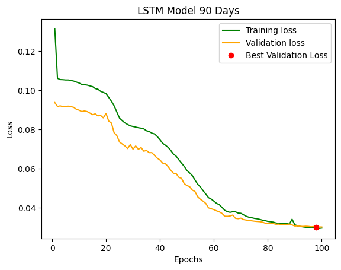

```python
# Get the training loss from the history
loss = history_90.history['loss']
# Get the validation loss from the history
val_loss = history_90.history['val_loss']

# Get the number of epochs
epochs = range(1, len(loss) + 1)

# Plot training loss in green
plt.plot(epochs, loss, 'g', label='Training loss')

# Find the epoch with the best validation loss
best_epoch = val_loss.index(min(val_loss)) + 1

# Plot validation loss in orange
plt.plot(epochs, val_loss, 'orange', label='Validation loss')
# Mark the epoch with the best validation loss
plt.plot(best_epoch, min(val_loss), 'ro', label='Best Validation Loss')

plt.title('LSTM Model 90 Days')
plt.xlabel('Epochs')
plt.ylabel('Loss')
plt.legend()
plt.show()
```

```python
with open("history_90.pkl", 'wb') as f:
    pickle.dump(history_90, f)
```

## c. 366 Days LSTM

Dan percobaan terakhir adalah menggunakan jangka waktu 366 hari untuk memprediksi sampah 2024

```python
model_LSTM_366 = tf.keras.Sequential()
model_LSTM_366.add(tf.keras.layers.LSTM(64, return_sequences=True, input_shape=(366, 3)))
model_LSTM_366.add(tf.keras.layers.LSTM(64, return_sequences=True))
model_LSTM_366.add(tf.keras.layers.LSTM(256, return_sequences=False))
model_LSTM_366.add(tf.keras.layers.Dense(1098, activation='relu'))
model_LSTM_366.add(tf.keras.layers.Reshape((366, 3)))
model_LSTM_366.summary()
```

```
Model: "sequential_22"
_________________________________________________________________
 Layer (type)                Output Shape              Param #
=================================================================
 lstm_46 (LSTM)              (None, 366, 64)           17408

 lstm_47 (LSTM)              (None, 366, 64)           33024

 lstm_48 (LSTM)              (None, 256)               328704

 dense_17 (Dense)            (None, 1098)              282186

 reshape_14 (Reshape)        (None, 366, 3)            0

=================================================================
Total params: 661322 (2.52 MB)
Trainable params: 661322 (2.52 MB)
Non-trainable params: 0 (0.00 Byte)
_________________________________________________________________
```

```python
model_LSTM_366.compile(optimizer='adam', loss='mse')
```

```python
checkpoint_366 = ModelCheckpoint('best_LSTM_366_model.h5', monitor='val_loss', save_best_only=True, verbose=1)
```

```python
history_366 = model_LSTM_366.fit(X_366, y_366, epochs=100, validation_split=0.2, callbacks=[checkpoint_366])
```

```
Epoch 1: val_loss improved from inf to 0.09401, saving model to best_LSTM_366_model.h5
```

```
Epoch 2: val_loss improved from 0.09401 to 0.09239, saving model to best_LSTM_366_model.h5
Epoch 3: val_loss improved from 0.09239 to 0.09211, saving model to best_LSTM_366_model.h5
Epoch 4: val_loss did not improve from 0.09211
Epoch 5: val_loss improved from 0.09211 to 0.09204, saving model to best_LSTM_366_model.h5
Epoch 6: val_loss improved from 0.09204 to 0.09194, saving model to best_LSTM_366_model.h5
Epoch 7: val_loss improved from 0.09194 to 0.09186, saving model to best_LSTM_366_model.h5
Epoch 8: val_loss improved from 0.09186 to 0.09160, saving model to best_LSTM_366_model.h5
Epoch 9: val_loss improved from 0.09160 to 0.09071, saving model to best_LSTM_366_model.h5
Epoch 10: val_loss improved from 0.09071 to 0.09042, saving model to best_LSTM_366_model.h5
Epoch 11: val_loss improved from 0.09042 to 0.08999, saving model to best_LSTM_366_model.h5
Epoch 12: val_loss improved from 0.08999 to 0.08920, saving model to best_LSTM_366_model.h5
Epoch 13: val_loss improved from 0.08920 to 0.08784, saving model to best_LSTM_366_model.h5
Epoch 14: val_loss improved from 0.08784 to 0.08690, saving model to best_LSTM_366_model.h5
Epoch 15: val_loss improved from 0.08690 to 0.08628, saving model to best_LSTM_366_model.h5
Epoch 16: val_loss improved from 0.08628 to 0.08556, saving model to best_LSTM_366_model.h5
Epoch 17: val_loss did not improve from 0.08556
Epoch 18: val_loss improved from 0.08556 to 0.08504, saving model to best_LSTM_366_model.h5
Epoch 19: val_loss improved from 0.08504 to 0.08459, saving model to best_LSTM_366_model.h5
Epoch 20: val_loss did not improve from 0.08459
Epoch 21: val_loss improved from 0.08459 to 0.08428, saving model to best_LSTM_366_model.h5
Epoch 22: val_loss did not improve from 0.08428
Epoch 23: val_loss improved from 0.08428 to 0.08408, saving model to best_LSTM_366_model.h5
Epoch 24: val_loss improved from 0.08408 to 0.08390, saving model to best_LSTM_366_model.h5
Epoch 25: val_loss improved from 0.08390 to 0.08358, saving model to best_LSTM_366_model.h5
Epoch 26: val_loss did not improve from 0.08358
Epoch 27: val_loss improved from 0.08358 to 0.08263, saving model to best_LSTM_366_model.h5
Epoch 28: val_loss improved from 0.08263 to 0.08257, saving model to best_LSTM_366_model.h5
Epoch 29: val_loss improved from 0.08257 to 0.08205, saving model to best_LSTM_366_model.h5
Epoch 30: val_loss did not improve from 0.08205
Epoch 31: val_loss improved from 0.08205 to 0.08178, saving model to best_LSTM_366_model.h5
Epoch 32: val_loss did not improve from 0.08178
Epoch 33: val_loss did not improve from 0.08178
Epoch 34: val_loss did not improve from 0.08178
Epoch 35: val_loss improved from 0.08178 to 0.08143, saving model to best_LSTM_366_model.h5
Epoch 36: val_loss improved from 0.08143 to 0.08120, saving model to best_LSTM_366_model.h5
Epoch 37: val_loss did not improve from 0.08120
Epoch 38: val_loss improved from 0.08120 to 0.08118, saving model to best_LSTM_366_model.h5
Epoch 39: val_loss improved from 0.08118 to 0.08093, saving model to best_LSTM_366_model.h5
Epoch 40: val_loss improved from 0.08093 to 0.08046, saving model to best_LSTM_366_model.h5
Epoch 41: val_loss improved from 0.08046 to 0.07967, saving model to best_LSTM_366_model.h5
```

[output cut: 44 more lines]

```
Epoch 86: val_loss improved from 0.03608 to 0.03587, saving model to best_LSTM_366_model.h5
Epoch 87: val_loss improved from 0.03587 to 0.03539, saving model to best_LSTM_366_model.h5
Epoch 88: val_loss did not improve from 0.03539
Epoch 89: val_loss improved from 0.03539 to 0.03494, saving model to best_LSTM_366_model.h5
Epoch 90: val_loss improved from 0.03494 to 0.03464, saving model to best_LSTM_366_model.h5
Epoch 91: val_loss improved from 0.03464 to 0.03402, saving model to best_LSTM_366_model.h5
Epoch 92: val_loss improved from 0.03402 to 0.03351, saving model to best_LSTM_366_model.h5
Epoch 93: val_loss improved from 0.03351 to 0.03337, saving model to best_LSTM_366_model.h5
Epoch 94: val_loss improved from 0.03337 to 0.03317, saving model to best_LSTM_366_model.h5
Epoch 95: val_loss did not improve from 0.03317
Epoch 96: val_loss improved from 0.03317 to 0.03310, saving model to best_LSTM_366_model.h5
Epoch 97: val_loss did not improve from 0.03310
Epoch 98: val_loss improved from 0.03310 to 0.03265, saving model to best_LSTM_366_model.h5
Epoch 99: val_loss did not improve from 0.03265
Epoch 100: val_loss improved from 0.03265 to 0.03227, saving model to best_LSTM_366_model.h5
```

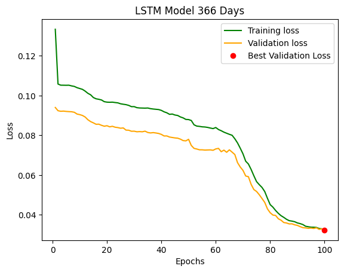

```python
# Get the training loss from the history
loss = history_366.history['loss']
# Get the validation loss from the history
val_loss = history_366.history['val_loss']

# Get the number of epochs
epochs = range(1, len(loss) + 1)

# Plot training loss in green
plt.plot(epochs, loss, 'g', label='Training loss')

# Find the epoch with the best validation loss
best_epoch = val_loss.index(min(val_loss)) + 1

# Plot validation loss in orange
plt.plot(epochs, val_loss, 'orange', label='Validation loss')
# Mark the epoch with the best validation loss
plt.plot(best_epoch, min(val_loss), 'ro', label='Best Validation Loss')

plt.title('LSTM Model 366 Days')
plt.xlabel('Epochs')
plt.ylabel('Loss')
plt.legend()
plt.show()
```

```python
with open("history_366.pkl", 'wb') as f:
    pickle.dump(history_366, f)
```